# Code for class project

Bonnie Smith

October 16, 2017

We need to use the development version of `rplos` from github in order for the `searchplos` function to work.

```r
install.packages("devtools")
devtools::install_github("ropensci/rplos")
```

```r
library(rplos)
library(knitr)
library(stringr)
library(rebus)
library(ggplot2)
```

### 1. Obtaining counts by journal

We obtain counts by journal for the number of articles in our dataset, using the `searchplos` function in the `rplos` package.

```r
#### Check that the filters in searchplos return the desired results

searchplos(q="*:*", fl=c("journal", "doc_type","article_type","publication_date"),
       fq=list('journal:"PLoS Genetics"', 'doc_type:full', 'article_type:"Research Article"'), sort="publication_date asc", limit=4)
```

```
## $meta
## # A tibble: 1 x 2
##   numFound start
##      <int> <int>
## 1     6210     0
##
## $data
## # A tibble: 4 x 4
##   doc_type       journal     publication_date     article_type
##      <chr>         <chr>                <chr>            <chr>
## 1     full PLoS Genetics 2005-06-17T00:00:00Z Research Article
## 2     full PLoS Genetics 2005-06-17T00:00:00Z Research Article
## 3     full PLoS Genetics 2005-07-25T00:00:00Z Research Article
## 4     full PLoS Genetics 2005-07-25T00:00:00Z Research Article
```

```r
### For each of the 6 journals of interest, find the total number of
###     research articles that have appeared over the life of the journal

counts=lapply( journal_list, function(x) searchplos(q="*",fq=list(x, 'doc_type:full',
           'article_type:"Research Article"'))$meta$numFound )

kable(matrix(counts,nrow=1),col.names=c("PLos Bio","PLoS Medicine", "PLoS Comp. Bio.","PLoS Genetics","PLoS Pathogens","PLoS Trop. Diseases"),caption="Total number of research articles that have appeared in each PLoS journal")


###  Restrict to articles that contain a Materials and Methods section

counts_mm= lapply( journal_list, function(x) searchplos(q="*",fq=list(x, 'doc_type:full',
           'article_type:"Research Article"','materials_and_methods:*'))$meta$numFound )

kable(matrix(counts_mm,nrow=1),col.names=c("PLos Bio","PLoS Medicine", "PLoS Comp. Bio.","PLoS Genetics","PLoS Pathogens","PLoS Trop. Diseases"),caption="Total number of research articles that have appeared in each PLoS journal")
```

### 2. Building the keyword list

We begin by taking a random sample of 12 research articles from each of the 6 journals, filtering on those journals that contain a materials and methods section.

```r
sample(1:2344,12)
sample(1:1370,12)
sample(1:4377,12)
sample(1:6165,12)
sample(1:5266,12)
sample(1:4746,12)
```

The results are fixed and recorded below. Next we read in the Materials and Methods section for each article in our sample. Each article is listed by its index when the research articles (having a materials and methods section) from that journal are listed chronologically by publication date. Note that due to constraints of working with the PLoS API, we read in one methods section at a time (to avoid a Server Error message).

```r
bio_samp=c(1000,1243,1986,1334,310,343,2063,1775,1587,1487,1287,439)

searchplos(q="materials_and_methods:*",fl=c('journal','materials_and_methods'), fq=c("doc_type:full", 'article_type:"Research Article"', 'journal:"PLoS Biology"'),sort='publication_date asc', start=439, limit=1)$data$materials_and_methods
```

```r
med_samp=c(31,1335,81,803,989,757,227,962,108,263,838,594)

searchplos(q="materials_and_methods:*",fl=c('journal','materials_and_methods'), fq=c("doc_type:full", 'article_type:"Research Article"', 'journal:"PLoS Medicine"'),sort='publication_date asc', start=594, limit=1)$data$materials_and_methods
```

```r
cb_samp=c(3711,3024,836,128,2225,4308,1442,1585,1283,695,2839,3539)

searchplos(q="materials_and_methods:*",fl=c('journal','materials_and_methods'), fq=c("doc_type:full", 'article_type:"Research Article"', 'journal:"PLoS Computational Biology"'),sort='publication_date asc', start=3539, limit=1)$data$materials_and_methods
```

```r
gen_samp=c(4649,3182,3688,4099,4339,2802,1897,3987,3940,4247,1658,2155)

searchplos(q="materials_and_methods:*",fl=c('journal','materials_and_methods'), fq=c("doc_type:full", 'article_type:"Research Article"', 'journal:"PLoS Genetics"'),sort='publication_date asc', start=2155, limit=1)$data$materials_and_methods
```

```r
path_samp=c(3467,2314,1019,2987,2940,1518,4433,1508,3698,5026,2426,216)

searchplos(q="materials_and_methods:*",fl=c('journal','materials_and_methods'), fq=c("doc_type:full", 'article_type:"Research Article"', 'journal:"PLoS Pathogens"'),sort='publication_date asc', start=216, limit=1)$data$materials_and_methods
```

```r
ntd_samp=c(107,2473,1075,1789,1321,3702,4214,2995,932,563,4572,3237)

searchplos(q="materials_and_methods:*",fl=c('journal','materials_and_methods'), fq=c("doc_type:full", 'article_type:"Research Article"', 'journal:"PLoS Neglected Tropical Diseases"'),sort='publication_date asc', start=3237, limit=1)$data$materials_and_methods
```

```r
### list for searching by journal

journal_list=c('journal:"PLoS Biology"','journal:"PLoS Medicine"','journal:"PLoS Computational Biology"','journal:"PLoS Genetics"','journal:"PLoS Pathogens"','journal:"PLoS Neglected Tropical Diseases"')

### list for searching keywords

word_list=c('materials_and_methods:ANOVA','materials_and_methods:"Benjamini-Hochberg"','materials_and_methods:"bootstrap"','materials_and_methods:"chi square"','materials_and_methods:clustering', 'materials_and_methods:"Cox proportional hazards"','materials_and_methods:"cross validation"','materials_and_methods:"Fisher exact test"', 'materials_and_methods:"generalized linear model"','materials_and_methods:"Kaplan-Meier"', 'materials_and_methods:"k-means"', 'materials_and_methods:"linear mixed model"','materials_and_methods:"linear regression"','materials_and_methods:"logistic regression"',   'materials_and_methods:"Mann-Whitney"', 'materials_and_methods:"Monte Carlo"', 'materials_and_methods:"principal components"', 'materials_and_methods:"ROC"','materials_and_methods:simulation',  'materials_and_methods:"t test"')
```

### 3. Counts and proportions for keyword-journal pairs

Next we get total article counts for each keyword-journal pairing. This is done in small batches, a few keywords at a time, to keep the PLoS API happy. (Adding a longer sleep time did not prevent a Server Error when we tried a for loop, looping over the 20 keywords, hence the clumsy workaround.)

```r
n=1
lapply(journal_list, function(x) searchplos(q=word_list[n],fl="publication_date",
       fq= list('doc_type:full', 'article_type:"Research Article"',x))$meta$numFound)

n=2
lapply(journal_list, function(x) searchplos(q=word_list[n],fl="publication_date",
       fq= list('doc_type:full', 'article_type:"Research Article"',x))$meta$numFound)

n=3
lapply(journal_list, function(x) searchplos(q=word_list[n],fl="publication_date",
       fq= list('doc_type:full', 'article_type:"Research Article"',x))$meta$numFound)

n=4
lapply(journal_list, function(x) searchplos(q=word_list[n],fl="publication_date",
       fq= list('doc_type:full', 'article_type:"Research Article"',x))$meta$numFound)
```

```r
n=5
lapply(journal_list, function(x) searchplos(q=word_list[n],fl="publication_date",
       fq= list('doc_type:full', 'article_type:"Research Article"',x))$meta$numFound)

n=6
lapply(journal_list, function(x) searchplos(q=word_list[n],fl="publication_date",
       fq= list('doc_type:full', 'article_type:"Research Article"',x))$meta$numFound)

n=7
lapply(journal_list, function(x) searchplos(q=word_list[n],fl="publication_date",
       fq= list('doc_type:full', 'article_type:"Research Article"',x))$meta$numFound)
```

```r
n=8
lapply(journal_list, function(x) searchplos(q=word_list[n],fl="publication_date",
       fq= list('doc_type:full', 'article_type:"Research Article"',x))$meta$numFound)


n=9
lapply(journal_list, function(x) searchplos(q=word_list[n],fl="publication_date",
       fq= list('doc_type:full', 'article_type:"Research Article"',x))$meta$numFound)


n=10
lapply(journal_list, function(x) searchplos(q=word_list[n],fl="publication_date",
       fq= list('doc_type:full', 'article_type:"Research Article"',x))$meta$numFound)
```

```r
n=11
lapply(journal_list, function(x) searchplos(q=word_list[n],fl="publication_date",
       fq= list('doc_type:full', 'article_type:"Research Article"',x))$meta$numFound)

n=12
lapply(journal_list, function(x) searchplos(q=word_list[n],fl="publication_date",
       fq= list('doc_type:full', 'article_type:"Research Article"',x))$meta$numFound)

n=13
lapply(journal_list, function(x) searchplos(q=word_list[n],fl="publication_date",
       fq= list('doc_type:full', 'article_type:"Research Article"',x))$meta$numFound)

n=14
lapply(journal_list, function(x) searchplos(q=word_list[n],fl="publication_date",
       fq= list('doc_type:full', 'article_type:"Research Article"',x))$meta$numFound)
```

```r
n=15
lapply(journal_list, function(x) searchplos(q=word_list[n],fl="publication_date",
       fq= list('doc_type:full', 'article_type:"Research Article"',x))$meta$numFound)

n=16
lapply(journal_list, function(x) searchplos(q=word_list[n],fl="publication_date",
       fq= list('doc_type:full', 'article_type:"Research Article"',x))$meta$numFound)

n=17
lapply(journal_list, function(x) searchplos(q=word_list[n],fl="publication_date",
       fq= list('doc_type:full', 'article_type:"Research Article"',x))$meta$numFound)
```

```r
n=18
lapply(journal_list, function(x) searchplos(q=word_list[n],fl="publication_date",
       fq= list('doc_type:full', 'article_type:"Research Article"',x))$meta$numFound)

n=19
lapply(journal_list, function(x) searchplos(q=word_list[n],fl="publication_date",
       fq= list('doc_type:full', 'article_type:"Research Article"',x))$meta$numFound)
n=20
lapply(journal_list, function(x) searchplos(q=word_list[n],fl="publication_date",
       fq= list('doc_type:full', 'article_type:"Research Article"',x))$meta$numFound)
```

The results of the preceding queries are recorded below. For n=1 to 20, wn is the 6-tuple of counts showing the number of articles containing the nth word in our keylist, for each of the 6 journals.

```r
#### For n=1 to 20, the vector wn gives the number of
####   articles with word n in each journal

w1=c(356,100,147,741,978,634)
w2=c(17,13,71,171,81,49)
w3=c(165,97,300,453,264,422)
w4=c(74,184,86,409,137,680)

w5=c(378,285,1150,1237,559,821)
w6=c(11,135,16,57,19,36)
w7=c(48,35,356,104,31,94)

w8=c(55,120,113,458,188,499)
w9=c(75,31,53,96,53,126)
w10=c(32,134,16,99,216,134)

w11=c(22,3,94,65,18,15)
w12=c(16,21,11,97,33,56)
w13=c(118,176,223,468,240,317)
w14=c(41,330,95,277,66,623)

w15=c(120,97,88,333,676,653)
w16=c(86,79,452,144,107,252)
w17=c(50,55,238,405,64,158)

w18=c(14,34,154,50,17,200)
w19=c(356,157,2608,634,225,367)
w20=c(1469,1093,2191,4354,3729,3958)

total=c(2367,1381,4747,6205,5280,4780)
```

We form the matrix of counts, and also the matrix showing what proportion of all of the journal’s articles use the keyword.

```r
### The matrix of counts for each word-journal pair

C=t(matrix(c(w1,w2,w3,w4,w5,w6,w7,w8,w9,w10,w11,w12,w13,w14,w15,w16,w17,w18,w19,w20,total),nrow=6))

C
```

```
##       [,1] [,2] [,3] [,4] [,5] [,6]
##  [1,]  356  100  147  741  978  634
##  [2,]   17   13   71  171   81   49
##  [3,]  165   97  300  453  264  422
##  [4,]   74  184   86  409  137  680
##  [5,]  378  285 1150 1237  559  821
##  [6,]   11  135   16   57   19   36
##  [7,]   48   35  356  104   31   94
##  [8,]   55  120  113  458  188  499
##  [9,]   75   31   53   96   53  126
## [10,]   32  134   16   99  216  134
## [11,]   22    3   94   65   18   15
## [12,]   16   21   11   97   33   56
## [13,]  118  176  223  468  240  317
## [14,]   41  330   95  277   66  623
## [15,]  120   97   88  333  676  653
## [16,]   86   79  452  144  107  252
## [17,]   50   55  238  405   64  158
## [18,]   14   34  154   50   17  200
## [19,]  356  157 2608  634  225  367
## [20,] 1469 1093 2191 4354 3729 3958
## [21,] 2367 1381 4747 6205 5280 4780
```

```r
### The matrix of proportions for each word-journal pair (out of
###    the total number of research articles for that journal)

P=round(t(matrix(c(w1/total,w2/total,w3/total,w4/total,w5/total,w6/total,w7/total,w8/total,w9/total,w10/total,w11/total,w12/total,w13/total,w14/total,w15/total,w16/total,w17/total,w18/total,w19/total,w20/total),nrow=6)),3)

P
```

```
##        [,1]  [,2]  [,3]  [,4]  [,5]  [,6]
##  [1,] 0.150 0.072 0.031 0.119 0.185 0.133
##  [2,] 0.007 0.009 0.015 0.028 0.015 0.010
##  [3,] 0.070 0.070 0.063 0.073 0.050 0.088
##  [4,] 0.031 0.133 0.018 0.066 0.026 0.142
##  [5,] 0.160 0.206 0.242 0.199 0.106 0.172
##  [6,] 0.005 0.098 0.003 0.009 0.004 0.008
##  [7,] 0.020 0.025 0.075 0.017 0.006 0.020
##  [8,] 0.023 0.087 0.024 0.074 0.036 0.104
##  [9,] 0.032 0.022 0.011 0.015 0.010 0.026
## [10,] 0.014 0.097 0.003 0.016 0.041 0.028
## [11,] 0.009 0.002 0.020 0.010 0.003 0.003
## [12,] 0.007 0.015 0.002 0.016 0.006 0.012
## [13,] 0.050 0.127 0.047 0.075 0.045 0.066
## [14,] 0.017 0.239 0.020 0.045 0.012 0.130
## [15,] 0.051 0.070 0.019 0.054 0.128 0.137
## [16,] 0.036 0.057 0.095 0.023 0.020 0.053
## [17,] 0.021 0.040 0.050 0.065 0.012 0.033
## [18,] 0.006 0.025 0.032 0.008 0.003 0.042
## [19,] 0.150 0.114 0.549 0.102 0.043 0.077
## [20,] 0.621 0.791 0.462 0.702 0.706 0.828
```

```r
P_trim=P[c(1,3:8,10,13:17,19,20),]
```

Results are recorded together for convenience:

```r
names(wj_df)=c("PLoS Biology", "PLoS Medicine", "PLoS Comp Bio","PLoS Genetics","PLoS Pathogens", "PLoS NTD")

row.names(wj_df)=c("ANOVA","Benjamini-Hochberg","bootstrap", "chi square","clustering", "Cox proportional hazards", "cross validation", "Fisher exact test", "generalized linear model","Kaplan-Meier", "k-means", "linear mixed model", "linear regression","logistic regression", "Mann-Whitney","Monte Carlo", "principal components", "ROC", "simulation", "t test", "TOTAL")


kable(wj_df,align='rrrrrr',caption="Table 3: **Total number (proportion) of journal's research articles containing the keyword.**  The first number in each cell is the total number of research articles published in the given journal in which the keyword appears in the Materials and Methods section.  The second number is the proportion of all research articles in that journal that contain the keyword.")
```

[output not shown]

Table showing articles with missing Methods sections:

```r
 counts_all=c(2367,1381,4747,6205,5280,4780)
 counts_mm=c(2344,1370,4377,6165,5266,4746)
 perc_mis=round(100*(counts_all-counts_mm)/counts_all, 2)
 percent_missing=c(.97,.8,7.79,.64,.27,.71)

x=data.frame(c("2367","2344",".97"),c("1381","1370",".8"),c("4747","4377","7.79"),c("6205","6165",".64"), c("5280","5266",".27"),c("4780","4746",".71"))

row.names(x)=c("Total # of articles", "# articles with a methods section", "% articles with no methods section")

kable(x,col.names=c("Biology","Medicine", "Comp. Bio.","Genetics","Pathogens","N.T.D."),align='cccccc', caption="**Counts of research articles, and percent missingness.**  For each journal, the total number of research articles, and the total number of research articles that contain a Materials and Methods section are shown, as well as the percent of that journal's research articles that are missing a Materials and Methods section.")
```

**Counts of research articles, and percent missingness.** For each journal, the total number of research articles, and the total number of research articles that contain a Materials and Methods section are shown, as well as the percent of that journal’s research articles that are missing a Materials and Methods section.

|  | Biology | Medicine | Comp. Bio. | Genetics | Pathogens | N.T.D. |
| --- | --- | --- | --- | --- | --- | --- |
| Total # of articles | 2367 | 1381 | 4747 | 6205 | 5280 | 4780 |
| # articles with a methods section | 2344 | 1370 | 4377 | 6165 | 5266 | 4746 |
| % articles with no methods section | .97 | .8 | 7.79 | .64 | .27 | .71 |

### 4. Code for results section

Code for Figure 1 of the report:

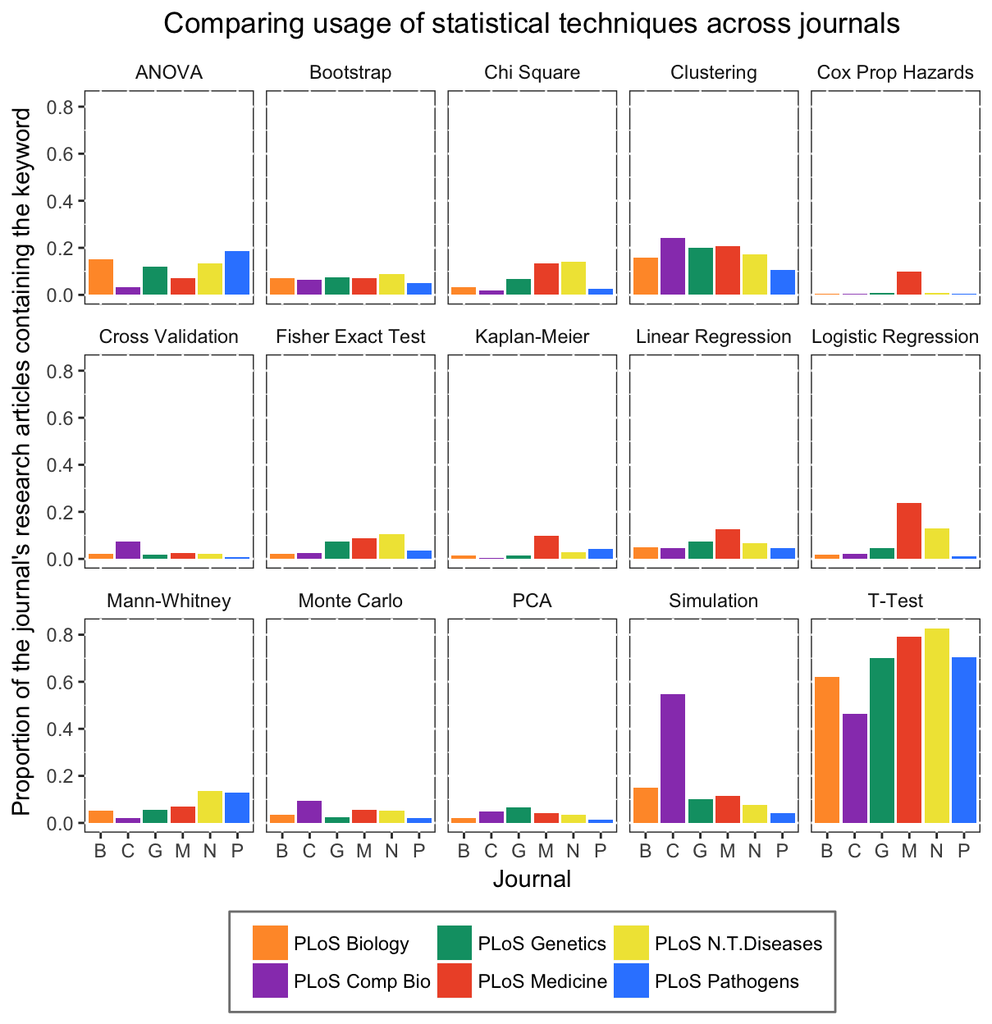

```r
V=as.vector(P_trim)

words=c("ANOVA","Bootstrap", "Chi Square","Clustering", "Cox Prop Hazards", "Cross Validation", "Fisher Exact Test","Kaplan-Meier", "Linear Regression","Logistic Regression", "Mann-Whitney","Monte Carlo", "PCA", "Simulation", "T-Test")

word_df=data.frame(rep(words,6), c(rep("PLoS Biology",15),rep("PLoS Medicine",15), rep("PLoS Comp Bio",15), rep("PLoS Genetics",15), rep("PLoS Pathogens",15), rep("PLoS N.T.Diseases",15) ), V)

names(word_df)=c("word","Journal","Proportions")

my_palette=c("#FF9933","#9944BB","#009E73", "#EE5533", "#F0E442","#3388FF")

ggplot(word_df,aes(x=Journal,fill=Journal,y=Proportions))+geom_bar(stat="identity")+facet_wrap(~word,nrow=3)+scale_x_discrete(labels=c("PLoS Biology"="B", "PLoS Comp Bio"="C", "PLoS Genetics"="G", "PLoS Medicine"="M", "PLoS N.T.Diseases"="N", "PLoS Pathogens"="P"))+labs(y="Proportion of the journal's research articles containing the keyword", title="Comparing usage of statistical techniques across journals")+scale_fill_manual(values=my_palette)+theme(plot.title=element_text(hjust=.5),legend.position="bottom",legend.title=element_blank(),legend.background=element_rect(colour="grey50"), strip.background=element_rect(fill=NA),panel.background=element_rect(fill="white",color="grey20"))
```

Code for table of standard deviations:

```r
sdVec=vector(length=15)
for(n in 1:15){
     sdVec[n]=round(sd(P_trim[n,]),3)
}

sd_df_1=as.data.frame(t(sdVec[1:8]))

names(sd_df_1)=c("ANOVA","Bootstrap","Chi square","Clustering","Cox prop.", "Cross val.","Fisher exact","Kaplan-Meier" )

kable(sd_df_1,align="cccccccc",caption="**Standard deviation in journal proportions for each keyword.**  For each keyword, we compute the standard deviation in the 6 values of proportionate usage by journal.")
```

**Standard deviation in journal proportions for each keyword.** For each keyword, we compute the standard deviation in the 6 values of proportionate usage by journal.

| ANOVA | Bootstrap | Chi square | Clustering | Cox prop. | Cross val. | Fisher exact | Kaplan-Meier |
| --- | --- | --- | --- | --- | --- | --- | --- |
| 0.055 | 0.012 | 0.055 | 0.047 | 0.038 | 0.024 | 0.035 | 0.034 |

```r
sd_df_2=as.data.frame(t(sdVec[9:15]))

names(sd_df_2)=c("Linear regr.", "Logistic regr.", "Mann-Whitney", "Monte Carlo", "PCA", "Simulation", "T test")

kable(sd_df_2,align="ccccccc")
```

| Linear regr. | Logistic regr. | Mann-Whitney | Monte Carlo | PCA | Simulation | T test |
| --- | --- | --- | --- | --- | --- | --- |
| 0.031 | 0.091 | 0.047 | 0.028 | 0.019 | 0.188 | 0.131 |

Code for table of differences between each pair of journals:

```r
sums_by_journal=vector(length=6)
for(n in 1:6){
      sums_by_journal[n]=sum(P[,n])
}


journal_Matrix=matrix(nrow=6,ncol=6)
for(n in 1:6){
     for(m in 1:6){
          journal_Matrix[n,m]=round(sum((P[,m]-P[,n])^2),3)
     }
}


difference=vector(length=6)
for(j in 1:6){
     difference[j]=sum(journal_Matrix[j,])
}

diff_df=data.frame(journal_Matrix[,1],journal_Matrix[,2],journal_Matrix[,3],journal_Matrix[,4],journal_Matrix[,5],journal_Matrix[,6],difference)

row.names(diff_df)=c("Bio","Med","CB","Gen","Path","NTD")
names(diff_df)=c("Bio","Med","CB","Gen","Path","NTD", "Row Sums")

kable(diff_df,caption="Pairwise 'distance' in keyword usage between journals")
```

Pairwise ‘distance’ in keyword usage between journals

|  | Bio | Med | CB | Gen | Path | NTD | Row Sums |
| --- | --- | --- | --- | --- | --- | --- | --- |
| Bio | 0.000 | 0.125 | 0.215 | 0.020 | 0.031 | 0.090 | 0.481 |
| Med | 0.125 | 0.000 | 0.397 | 0.073 | 0.126 | 0.042 | 0.763 |
| CB | 0.215 | 0.397 | 0.000 | 0.285 | 0.385 | 0.427 | 1.709 |
| Gen | 0.020 | 0.073 | 0.285 | 0.000 | 0.031 | 0.042 | 0.451 |
| Path | 0.031 | 0.126 | 0.385 | 0.031 | 0.000 | 0.061 | 0.634 |
| NTD | 0.090 | 0.042 | 0.427 | 0.042 | 0.061 | 0.000 | 0.662 |

### 5: Time specific information

Next, we make comparisons between two time periods of interest: 2009-2010, and 2016-2017. For certain word-journal pairs, we extract the counts for articles published in each of these time periods. This is straightforward if the total count for that word-journal pair is < 1000. (1000 is the maximum number of articles that the `searchplos` function will return on a single call.) Otherwise, the query must be done in batches of <1000, and the results summed.

We also obtain the total counts of articles for each journal for these two time periods, since, as before, our interest will be in the proportion of articles that use the keyword.

```r
###  PLoS Biology

j=1
for(w in c(1,3,5,13,15,19,20)){
list=searchplos(word_list[w],fl="publication_date",
           fq= list('doc_type:full','article_type:"Research Article"', journal_list[j]), limit=900, sort='publication_date asc' )$data$publication_date

print( c(word_list[w], sum(str_detect(list,pattern=or("2009","2010") ) ), sum(str_detect(list,pattern=or("2016","2017"))), sum(str_detect(list,pattern="20")) ) )
}

list=searchplos(word_list[20],fl="publication_date",
           fq= list('doc_type:full','article_type:"Research Article"', journal_list[j]), start=900, limit=600, sort='publication_date asc' )$data$publication_date

print( c(word_list[w], sum(str_detect(list,pattern=or("2009","2010") ) ), sum(str_detect(list,pattern=or("2016","2017"))), sum(str_detect(list,pattern="20")) ) )

for(n in 1:3){
list=searchplos(q='*',fl="publication_date",
           fq= list('doc_type:full','article_type:"Research Article"', journal_list[j]), start=(n*900-900), limit=900, sort='publication_date asc' )$data$publication_date

print( c(sum(str_detect(list,pattern=or("2009","2010") ) ), sum(str_detect(list,pattern=or("2016","2017"))), sum(str_detect(list,pattern="20")) ) )
}
```

```r
### PLoS Medicine

j=2
for(w in c(4,5,6,10,13,14,19,20)){
list=searchplos(word_list[w],fl="publication_date",
           fq= list('doc_type:full','article_type:"Research Article"', journal_list[j]), limit=900, sort='publication_date asc' )$data$publication_date

print( c(word_list[w], sum(str_detect(list,pattern=or("2009","2010") ) ), sum(str_detect(list,pattern=or("2016","2017"))), sum(str_detect(list,pattern="20")) ) )
}

list=searchplos(word_list[20],fl="publication_date",
           fq= list('doc_type:full','article_type:"Research Article"', journal_list[j]), start=900, limit=600, sort='publication_date asc' )$data$publication_date

print( c(word_list[w], sum(str_detect(list,pattern=or("2009","2010") ) ), sum(str_detect(list,pattern=or("2016","2017"))), sum(str_detect(list,pattern="20")) ) )

for(n in 1:2){
list=searchplos(q='*',fl="publication_date",
           fq= list('doc_type:full','article_type:"Research Article"', journal_list[j]), start=(n*900-900), limit=900, sort='publication_date asc' )$data$publication_date

print( c(sum(str_detect(list,pattern=or("2009","2010") ) ), sum(str_detect(list,pattern=or("2016","2017"))), sum(str_detect(list,pattern="20")) ) )
}
```

```r
### PLoS Computational Bio

j=3
for(w in c(3,5,7,16,17,19,20)){
list=searchplos(word_list[w],fl="publication_date",
           fq= list('doc_type:full','article_type:"Research Article"', journal_list[j]), limit=900, sort='publication_date asc' )$data$publication_date

print( c(word_list[w], sum(str_detect(list,pattern=or("2009","2010") ) ), sum(str_detect(list,pattern=or("2016","2017"))), sum(str_detect(list,pattern="20")) ) )
}

for(w in c(5,19,20)){
list=searchplos(word_list[w],fl="publication_date",
           fq= list('doc_type:full','article_type:"Research Article"', journal_list[j]), start=900, limit=900, sort='publication_date asc' )$data$publication_date

print( c(word_list[w], sum(str_detect(list,pattern=or("2009","2010") ) ), sum(str_detect(list,pattern=or("2016","2017"))), sum(str_detect(list,pattern="20")) ) )
}

for(w in c(19,20)){
list=searchplos(word_list[w],fl="publication_date",
           fq= list('doc_type:full','article_type:"Research Article"', journal_list[j]), start=1800, limit=900, sort='publication_date asc' )$data$publication_date

print( c(word_list[w], sum(str_detect(list,pattern=or("2009","2010") ) ), sum(str_detect(list,pattern=or("2016","2017"))), sum(str_detect(list,pattern="20")) ) )
}

for(n in 1:6){
list=searchplos(q='*',fl="publication_date",
           fq= list('doc_type:full','article_type:"Research Article"', journal_list[j]), start=(n*900-900), limit=900, sort='publication_date asc' )$data$publication_date

print( c(sum(str_detect(list,pattern=or("2009","2010") ) ), sum(str_detect(list,pattern=or("2016","2017"))), sum(str_detect(list,pattern="20")) ) )
}
```

```r
### PLoS Genetics

j=4
for(w in c(1,3,5,8,13,19,20)){
list=searchplos(word_list[w],fl="publication_date",
           fq= list('doc_type:full','article_type:"Research Article"', journal_list[j]), limit=900, sort='publication_date asc' )$data$publication_date

print( c(word_list[w], sum(str_detect(list,pattern=or("2009","2010") ) ), sum(str_detect(list,pattern=or("2016","2017"))), sum(str_detect(list,pattern="20")) ) )
}

for(w in c(5,20)){
list=searchplos(word_list[w],fl="publication_date",
           fq= list('doc_type:full','article_type:"Research Article"', journal_list[j]), start=900, limit=900, sort='publication_date asc' )$data$publication_date

print( c(word_list[w], sum(str_detect(list,pattern=or("2009","2010") ) ), sum(str_detect(list,pattern=or("2016","2017"))), sum(str_detect(list,pattern="20")) ) )
}

for(n in 3:5){
list=searchplos(word_list[20],fl="publication_date",
           fq= list('doc_type:full','article_type:"Research Article"', journal_list[j]), start=900*(n-1), limit=900, sort='publication_date asc' )$data$publication_date

print( c(word_list[20], sum(str_detect(list,pattern=or("2009","2010") ) ), sum(str_detect(list,pattern=or("2016","2017"))), sum(str_detect(list,pattern="20")) ) )
}

for(n in 1:7){
list=searchplos(q='*',fl="publication_date",
           fq= list('doc_type:full','article_type:"Research Article"', journal_list[j]), start=(n*900-900), limit=900, sort='publication_date asc' )$data$publication_date

print( c(sum(str_detect(list,pattern=or("2009","2010") ) ), sum(str_detect(list,pattern=or("2016","2017"))), sum(str_detect(list,pattern="20")) ) )
}
```

```r
### PLoS Pathogens

j=5
for(w in c(1,3,5,13,15,20)){
list=searchplos(word_list[w],fl="publication_date",
           fq= list('doc_type:full','article_type:"Research Article"', journal_list[j]), limit=900, sort='publication_date asc' )$data$publication_date

print( c(word_list[w], sum(str_detect(list,pattern=or("2009","2010") ) ), sum(str_detect(list,pattern=or("2016","2017"))), sum(str_detect(list,pattern="20")) ) )
}

n=2
list=searchplos(word_list[1],fl="publication_date",
           fq= list('doc_type:full','article_type:"Research Article"', journal_list[j]), start=900*(n-1), limit=900, sort='publication_date asc' )$data$publication_date

print( c(word_list[1], sum(str_detect(list,pattern=or("2009","2010") ) ), sum(str_detect(list,pattern=or("2016","2017"))), sum(str_detect(list,pattern="20")) ) )

for(n in 2:5){
list=searchplos(word_list[20],fl="publication_date",
           fq= list('doc_type:full','article_type:"Research Article"', journal_list[j]), start=900*(n-1), limit=900, sort='publication_date asc' )$data$publication_date

print( c(word_list[20], sum(str_detect(list,pattern=or("2009","2010") ) ), sum(str_detect(list,pattern=or("2016","2017"))), sum(str_detect(list,pattern="20")) ) )
}

for(n in 1:6){
list=searchplos(q='*',fl="publication_date",
           fq= list('doc_type:full','article_type:"Research Article"', journal_list[j]), start=(n*900-900), limit=900, sort='publication_date asc' )$data$publication_date

print( c(sum(str_detect(list,pattern=or("2009","2010") ) ), sum(str_detect(list,pattern=or("2016","2017"))), sum(str_detect(list,pattern="20")) ) )
}
```

```r
### PLoS N.T.Diseases

j=6
for(w in c(1,3,4,5,8,14,15,20)){
list=searchplos(word_list[w],fl="publication_date",
           fq= list('doc_type:full','article_type:"Research Article"', journal_list[j]), limit=900, sort='publication_date asc' )$data$publication_date

print( c(word_list[w], sum(str_detect(list,pattern=or("2009","2010") ) ), sum(str_detect(list,pattern=or("2016","2017"))), sum(str_detect(list,pattern="20")) ) )
}

for(n in 2:5){
list=searchplos(word_list[20],fl="publication_date",
           fq= list('doc_type:full','article_type:"Research Article"', journal_list[j]), start=900*(n-1), limit=900, sort='publication_date asc' )$data$publication_date

print( c(word_list[20], sum(str_detect(list,pattern=or("2009","2010") ) ), sum(str_detect(list,pattern=or("2016","2017"))), sum(str_detect(list,pattern="20")) ) )
}

for(n in 1:6){
list=searchplos(q='*',fl="publication_date",
           fq= list('doc_type:full','article_type:"Research Article"', journal_list[j]), start=(n*900-900), limit=900, sort='publication_date asc' )$data$publication_date

print( c(sum(str_detect(list,pattern=or("2009","2010") ) ), sum(str_detect(list,pattern=or("2016","2017"))), sum(str_detect(list,pattern="20")) ) )
}
```

**The code for this function is copied from the website and pasted below.**

```r
####### Multiplot function from www.cookbook-r.com
#######    NOT my own code!!

multiplot <- function(..., plotlist=NULL, file, cols=1, layout=NULL) {
  library(grid)

  # Make a list from the ... arguments and plotlist
  plots <- c(list(...), plotlist)

  numPlots = length(plots)

  # If layout is NULL, then use 'cols' to determine layout
  if (is.null(layout)) {
    # Make the panel
    # ncol: Number of columns of plots
    # nrow: Number of rows needed, calculated from # of cols
    layout <- matrix(seq(1, cols * ceiling(numPlots/cols)),
                    ncol = cols, nrow = ceiling(numPlots/cols))
  }

 if (numPlots==1) {
    print(plots[[1]])

  } else {
    # Set up the page
    grid.newpage()
    pushViewport(viewport(layout = grid.layout(nrow(layout), ncol(layout))))

    # Make each plot, in the correct location
    for (i in 1:numPlots) {
      # Get the i,j matrix positions of the regions that contain this subplot
      matchidx <- as.data.frame(which(layout == i, arr.ind = TRUE))

      print(plots[[i]], vp = viewport(layout.pos.row = matchidx$row,
                                      layout.pos.col = matchidx$col))
    }
  }
}
```

**Prevalance of selected statistical techniques in PLoS journals, 2009-10 vs. 2016-17**

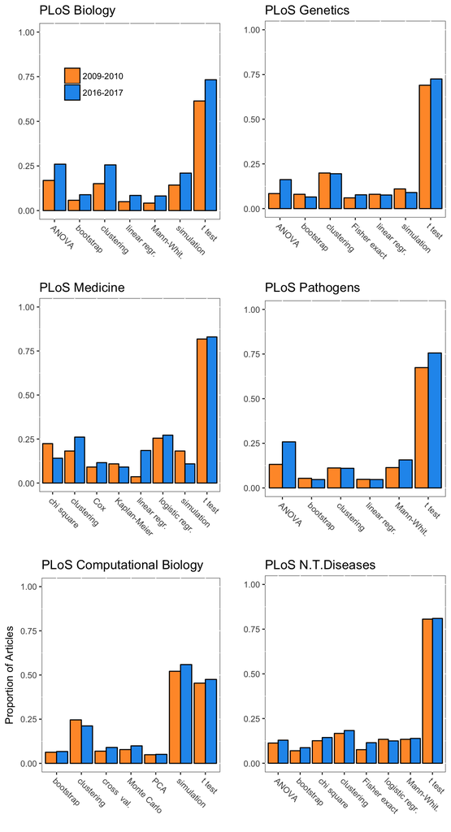

**Changes in usage between 2009-10 to 2016-17, by journal.** Each measure is summed over the keywords chosen for that journal, as displayed in Figure 2.

|  | Biology | Medicine | Comp.Bio. | Genetics | Pathogens | N.T.Diseases |
| --- | --- | --- | --- | --- | --- | --- |
| Sum for 2009-10 | 1.227 | 1.897 | 1.480 | 1.303 | 1.134 | 1.626 |
| Sum for 2016-17 | 1.715 | 2.005 | 1.553 | 1.390 | 1.375 | 1.732 |
| Sum of changes | 0.488 | 0.108 | 0.073 | 0.087 | 0.241 | 0.106 |
| Sum of \|changes\| | 0.488 | 0.456 | 0.141 | 0.173 | 0.261 | 0.124 |